# Parte 1 - ggplot2

Fabrício Dalvi Venturim

12/05/2022

Bibliotecas para o markdown:

```r
library("knitr")
library("kableExtra")
library("htmltools")
```

```r
if(!require(ggplot2)) install.packages("ggplot2")
library(ggplot2)

if(!require(dplyr)) install.packages("dplyr")
library(dplyr)

if(!require(ggthemes)) install.packages("ggthemes")
library(ggthemes)
```

O banco de dados utilizados na parte 1 do trabalho foi:

https://github.com/adaoduque/Brasileirao_Dataset

```r
dados = read.csv("campeonato-brasileiro-full.csv")
```

# 1 Curiosidade e propósito

Assim como no Case Sudy do Capítulo 3 do livro do Andy Kirk, sempre fui fanático por futebol e toda a estatística que busca explicar esse esporte. Nos dias de hoje, o que mais se ouve nas televisões, sites e vídeos são estatísticas e informações sobre o mundo do futebol e suas peculiaridades.

Por conta disso, resolvi pegar um banco de dados sobre o campeonato brasileiro, a fim de realizar algumas análises e tirar conclusões.

## 1.1 Estudar as variáveis do banco de dados

Uma boa forma de iniciar uma análise exploratória de dados é entender e classificar os tipos de variáveis do banco de dados.

Vamos ver o banco de dados:

```r
str(dados)
```

```
## 'data.frame':    7645 obs. of  19 variables:
##  $ ID                : int  1 2 3 4 5 6 7 8 9 10 ...
##  $ rodada            : int  1 1 1 1 1 1 1 1 1 1 ...
##  $ Temporada         : int  2003 2003 2003 2003 2003 2003 2003 2003 2003 2003 ...
##  $ data              : chr  "2003-03-29" "2003-03-29" "2003-03-30" "2003-03-30" ...
##  $ hora              : chr  "16:00" "16:00" "16:00" "16:00" ...
##  $ dia               : chr  "Sabado" "Sabado" "Domingo" "Domingo" ...
##  $ mandante          : chr  "Guarani" "Athletico-PR" "Flamengo" "Goias" ...
##  $ visitante         : chr  "Vasco" "Gremio" "Coritiba" "Paysandu" ...
##  $ formacao_mandante : chr  "" "" "" "" ...
##  $ formacao_visitante: chr  "" "" "" "" ...
##  $ tecnico_mandante  : chr  "" "" "" "" ...
##  $ tecnico_visitante : chr  "" "" "" "" ...
##  $ vencedor          : chr  "Guarani" "Athletico-PR" "-" "-" ...
##  $ arena             : chr  "brinco de ouro" "arena da baixada" "maracana" "serra dourada" ...
##  $ mandante_placar   : int  4 2 1 2 1 2 2 0 2 1 ...
##  $ visitante_placar  : int  2 0 1 2 1 0 2 0 2 1 ...
##  $ mandante_estado   : chr  "SP" "PR" "RJ" "GO" ...
##  $ visitante_estado  : chr  "RJ" "RS" "PR" "PA" ...
##  $ estado_vencedor   : chr  "SP" "PR" "-" "-" ...
```

```r
head(dados)
```

```
##   ID rodada Temporada       data  hora     dia      mandante   visitante
## 1  1      1      2003 2003-03-29 16:00  Sabado       Guarani       Vasco
## 2  2      1      2003 2003-03-29 16:00  Sabado  Athletico-PR      Gremio
## 3  3      1      2003 2003-03-30 16:00 Domingo      Flamengo    Coritiba
## 4  4      1      2003 2003-03-30 16:00 Domingo         Goias    Paysandu
## 5  5      1      2003 2003-03-30 16:00 Domingo Internacional Ponte Preta
## 6  6      1      2003 2003-03-30 16:00 Domingo      Criciuma  Fluminense
##   formacao_mandante formacao_visitante tecnico_mandante tecnico_visitante
## 1
## 2
## 3
## 4
## 5
## 6
##       vencedor            arena mandante_placar visitante_placar
## 1      Guarani   brinco de ouro               4                2
## 2 Athletico-PR arena da baixada               2                0
## 3            -         maracana               1                1
## 4            -    serra dourada               2                2
## 5            -        beira rio               1                1
## 6     Criciuma  heriberto hulse               2                0
##   mandante_estado visitante_estado estado_vencedor
## 1              SP               RJ              SP
## 2              PR               RS              PR
## 3              RJ               PR               -
## 4              GO               PA               -
## 5              RS               SP               -
## 6              SC               RJ              SC
```

```r
tail(dados)
```

```
##        ID rodada Temporada       data  hora     dia   mandante     visitante
## 7640 7640     38      2021 2021-12-12 21:33 Domingo America-MG     Sao Paulo
## 7641 7641     38      2021 2021-12-12 21:33 Domingo Bragantino Internacional
## 7642 7642     38      2021 2021-12-12 21:30 Domingo      Sport  Athletico-PR
## 7643 7643     38      2021 2021-12-12 21:33 Domingo  Juventude   Corinthians
## 7644 7644     38      2021 2021-12-12 21:33 Domingo     Gremio   Atletico-MG
## 7645 7645     38      2021 2021-12-12 21:33 Domingo     Santos        Cuiaba
##      formacao_mandante formacao_visitante    tecnico_mandante
## 7640           4-2-3-1            3-4-1-2             R. Ceni
## 7641           4-2-3-1            3-4-2-1  D. Aguirre Camblor
## 7642           4-2-3-1            3-4-2-1          J. Freitas
## 7643             3-4-3              4-3-3    S. Campos Junior
## 7644           4-2-3-1            4-2-3-1           A. Stival
## 7645           3-4-2-1              4-4-2 J. de Amorim Campos
##        tecnico_visitante   vencedor                    arena mandante_placar
## 7640             R. Ceni America-MG estadio raimundo sampaio               2
## 7641  D. Aguirre Camblor Bragantino                  nabizao               1
## 7642          J. Freitas          -      arena de pernambuco               1
## 7643    S. Campos Junior  Juventude           alfredo jaconi               1
## 7644           A. Stival     Gremio          arena do gremio               4
## 7645 J. de Amorim Campos          -  estadio urbano caldeira               1
##      visitante_placar mandante_estado visitante_estado estado_vencedor
## 7640                0              MG               SP              MG
## 7641                0              SP               RS              SP
## 7642                1              PE               PR               -
## 7643                0              RS               SP              RS
## 7644                3              RS               MG              RS
## 7645                1              SP               MT               -
```

Temos que a classificação das variáveis é a seguinte:

- Qualitativas:
  - `dia`, `mandante`, `visitante`, `vencedor`, `formacao_mandante`, `formacao_visitante`, `tecnico_mandante`, `tecnico_visitante`, `arena`, `mandante_estado`, `visitante_estado`, `estado_vencedor`.
- Quantitativas:
  - `rodada`, `temporada`, `hora`, `data`, `mandante_placar`, `visitante_placar`.

Agora que classificamos as variáveis, vamos fazer algumas **análises univariada**.

## 1.2 Análise univariada

Como eu peguei esta base da internet, certas variáveis(colunas) não me interessam muito a princípio. Portanto, vou trabalhar com as mais importante, e, caso necessário, utilizo as demais.

### 1.2.1 Variável Qualitativa

Com as variáveis `vencedor`, `arena`, `estado_vencedor`, `formacao_mandante`, `formacao_visitante`, `hora` e `dia` podemos obter uma tabela de frequência, um gráfico de barras ou setores e, por fim, a moda:

#### 1.2.1.1 `vencedor`:

frequência:

```r
tabela <- dados %>%
  group_by(vencedor) %>%
  summarize(N = n()) %>%
  mutate(freq = N / sum(N), pct = round((freq*100),0))
tabela <- tabela[order(tabela$N,decreasing=TRUE),]
```

Vamos plotar um gráfico para ter essas informaçoes visualmente:

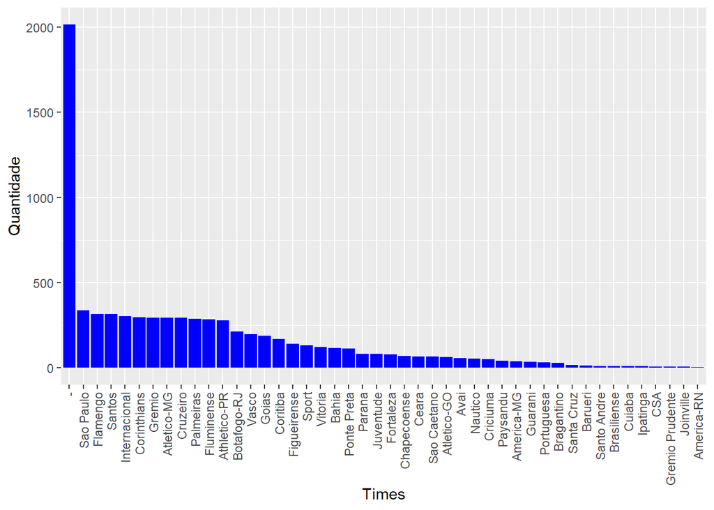

```r
# Ordenar da maior quantidade de vitórias para a menor
idx <- order(tabela$N, decreasing = TRUE)
levels <- tabela$vencedor[idx]
tabela$vencedor <- factor(tabela$vencedor, levels=levels, ordered=TRUE)

# Gráfico
p <- ggplot(tabela, aes(x = vencedor, y = N))
p + geom_col(position = "dodge2", fill = 'blue') +
  labs(x = "Times", y = "Quantidade") +
  theme(legend.position = "top",
        axis.text.x = element_text(angle = 90,
                                   vjust = 0.5,
                                   hjust = 1))
```

Percebe-se que não ficou muito legal de visualizar por conta da quantidade de times. Então, vamos ver apenas os times com mais vitórias.

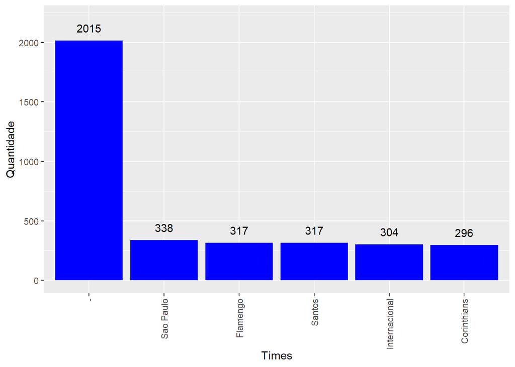

```r
# Ordenar da maior quantidade de vitórias para a menor
idx <- order(tabela$N, decreasing = TRUE)
levels <- tabela$vencedor[idx]
tabela$vencedor <- factor(tabela$vencedor, levels=levels, ordered=TRUE)

# Gráfico
p <- ggplot(head(tabela), aes(x = vencedor, y = N))
p + geom_col(position = "dodge2", fill = 'blue') +
  labs(x = "Times", y = "Quantidade") +
  theme(legend.position = "top",
        axis.text.x = element_text(angle = 90,
                                   vjust = 0.5,
                                   hjust = 1)) +
  geom_text(aes(label = N), vjust = -1) +
  ylim(0,2200)
```

**Percebe-se que, desconsiderando a quantidade de empates (-), os times que mais venceram foram o São Paulo(338), Flamengo(317), Santos(317), Internacional(304) e Corinthians(296).**

**Além disso, de 2003 até 2021, houveram 2015 empates, o que, considerando que tiveram 7645 jogos, representa 26,35% dos resultados dos jogos.**

#### 1.2.1.2 `arena`:

Vamos repeti o mesmo código, mas agora analisando a `arena`:

```r
tabela <- dados %>%
  group_by(arena) %>%
  summarize(N = n()) %>%
  mutate(freq = N / sum(N), pct = round((freq*100),0))
tabela <- tabela[order(tabela$N,decreasing=TRUE),]
```

Vamos plotar um gráfico para ter essas informaçoes visualmente:

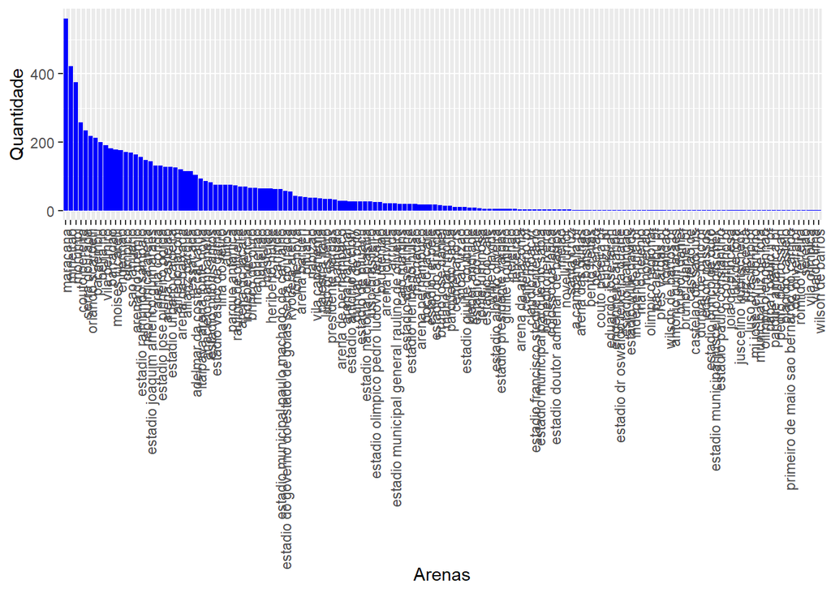

```r
# Ordenar da maior quantidade de vitórias para a menor
idx <- order(tabela$N, decreasing = TRUE)
levels <- tabela$arena[idx]
tabela$arena <- factor(tabela$arena, levels=levels, ordered=TRUE)

# Gráfico
p <- ggplot(tabela, aes(x = arena, y = N))
p + geom_col(position = "dodge2", fill = 'blue') +
  labs(x = "Arenas", y = "Quantidade") +
  theme(legend.position = "top",
        axis.text.x = element_text(angle = 90,
                                   vjust = 0.5,
                                   hjust = 1))
```

Novamento, vamos pegar os primeiros:

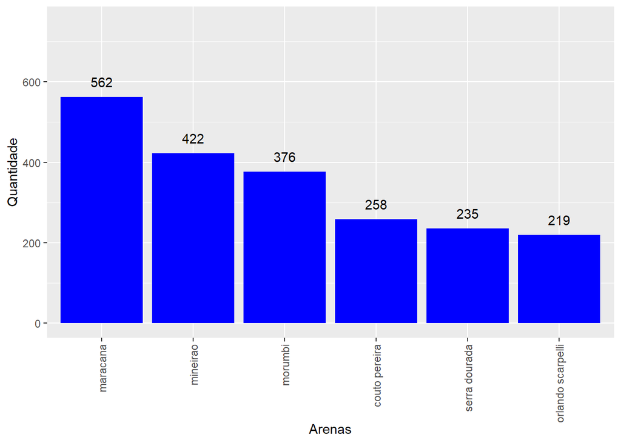

```r
# Ordenar da maior quantidade de vitórias para a menor
idx <- order(tabela$N, decreasing = TRUE)
levels <- tabela$arena[idx]
tabela$arena <- factor(tabela$arena, levels=levels, ordered=TRUE)

# Gráfico
p <- ggplot(head(tabela), aes(x = arena, y = N))
p + geom_col(position = "dodge2", fill = 'blue') +
  labs(x = "Arenas", y = "Quantidade") +
  theme(legend.position = "top",
        axis.text.x = element_text(angle = 90,
                                   vjust = 0.5,
                                   hjust = 1)) +
  geom_text(aes(label = N), vjust = -1) +
  ylim(0, 750)
```

**Ao tentar colocar todos as arenas que houve jogos, percebe-se que fica praticamente impossível de visualizar, visto que há uma quantidade gigantesca de estádios no Brasil.**

**Quando olhamos paraas arenas que tiveram mais jogos, percebemos que os que houvera mais jogos foram o Maracanã (Flamengo e Fluminense), Minerão (Cruzeiro e Atlético Mg), Morumbi(São Paulo), Couto Pereira (Coritiba) e Serra Dourada(Goiás).**

#### 1.2.1.3 `estado_vencedor`:

Vamos repeti o mesmo código, mas agora analisando a `estado_vencedor`:

```r
tabela <- dados %>%
  group_by(estado_vencedor) %>%
  summarize(N = n()) %>%
  mutate(freq = N / sum(N), pct = round((freq*100),0))
tabela <- tabela[order(tabela$N,decreasing=TRUE),]
```

Vamos plotar um gráfico para ter essas informaçoes visualmente:

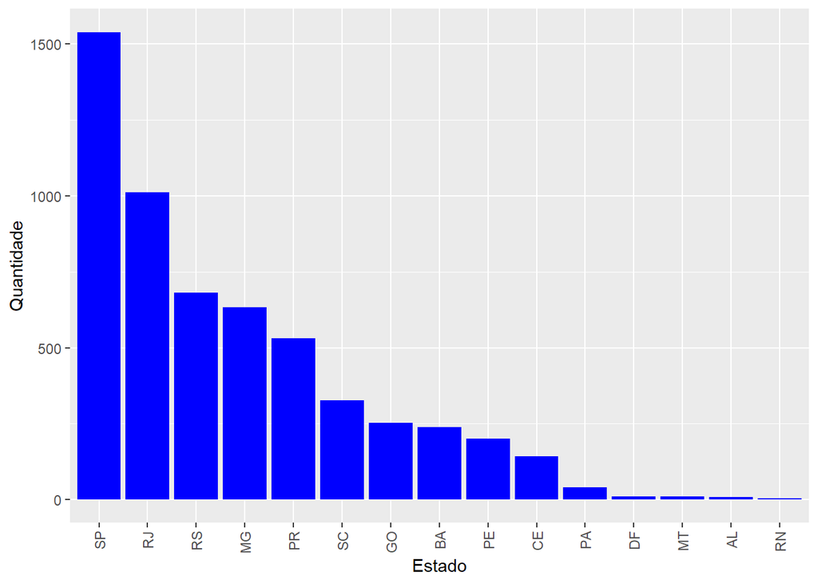

```r
# Ordenar da maior quantidade de vitórias para a menor
idx <- order(tabela$N, decreasing = TRUE)
levels <- tabela$estado_vencedor[idx]
tabela$estado_vencedor <- factor(tabela$estado_vencedor, levels=levels, ordered=TRUE)

estados <- c("SP", "RJ", "RS", "MG", "PR","SC","GO","BA","PE","CE","PA","DF","MT","AL","RN")

# Gráfico
p <- tabela %>% filter(tabela$estado_vencedor%in%estados) %>%  ggplot(aes(x = estado_vencedor, y = N))

p + geom_col(position = "dodge2", fill = 'blue') +
  labs(x = "Estado", y = "Quantidade") +
  theme(legend.position = "top",
        axis.text.x = element_text(angle = 90,
                                   vjust = 0.5,
                                   hjust = 1))
```

**Percebe-se que, desconsiderando a quantidade de empates (-), os estados que tiveram mais times vencedores foram São Paulo, Rio de Janiero, Rio Grande do Sul, Minas Gerais e Paraná.**

**Algo interessante é que, considerando os times que mais venceram: São Paulo, Flamengo, Santos, Internacional e Corinthians, temos que eles pertence aos 3 estados que mais ganharam, sendo São Paulo, Santos e Corinthians de SP.**

#### 1.2.1.4 `formacao_mandante`:

Vamos repeti o mesmo código, mas agora analisando a `formacao_mandante`:

```r
tabela <- dados %>%
  group_by(formacao_mandante) %>%
  summarize(N = n()) %>%
  mutate(freq = N / sum(N), pct = round((freq*100),0))
tabela <- tabela[order(tabela$N,decreasing=TRUE),]
```

Vamos plotar um gráfico para ter essas informaçoes visualmente:

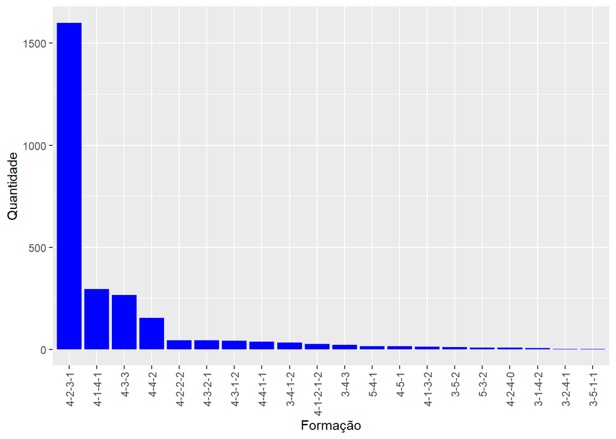

```r
# Ordenar da maior quantidade de vitórias para a menor
idx <- order(tabela$N, decreasing = TRUE)
levels <- tabela$formacao_mandante[idx]
tabela$formacao_mandante <- factor(tabela$formacao_mandante, levels=levels, ordered=TRUE)

formacoes <- c("4-2-3-1","4-1-4-1","4-3-3","4-4-2","4-2-2-2","4-3-2-1","4-3-1-2","4-4-1-1","3-4-1-2","3-4-1-2","4-1-2-1-2","3-4-3","5-4-1","4-5-1","4-1-3-2","3-5-2","5-3-2","4-2-4-0", "3-1-4-2", "3-2-4-1", "3-5-1-1")

# Gráfico
p <- tabela %>% filter(tabela$formacao_mandante%in%formacoes) %>% ggplot(aes(x = formacao_mandante, y = N), na.rm = FALSE)

p + geom_col(position = "dodge2", fill = 'blue') +
  labs(x = "Formação", y = "Quantidade") +
  theme(legend.position = "top",
        axis.text.x = element_text(angle = 90,
                                   vjust = 0.5,
                                   hjust = 1))
```

**Portanto, a formação 4-2-3-1 é praticamente predominante nos times mandantes do campeonato brasileiro, sendo 4-1-4-1, 4-3-3 e 4-4-2 as outras mais utilizadas.**

**Algo legal de ver é se esses números mudam quando analisamos os times visitantes:**

#### 1.2.1.5 `formacao_visitante`:

Vamos repeti o mesmo código, mas agora analisando a `formacao_visitante`:

```r
tabela <- dados %>%
  group_by(formacao_visitante) %>%
  summarize(N = n()) %>%
  mutate(freq = N / sum(N), pct = round((freq*100),0))
tabela <- tabela[order(tabela$N,decreasing=TRUE),]
```

Vamos plotar um gráfico para ter essas informaçoes visualmente:

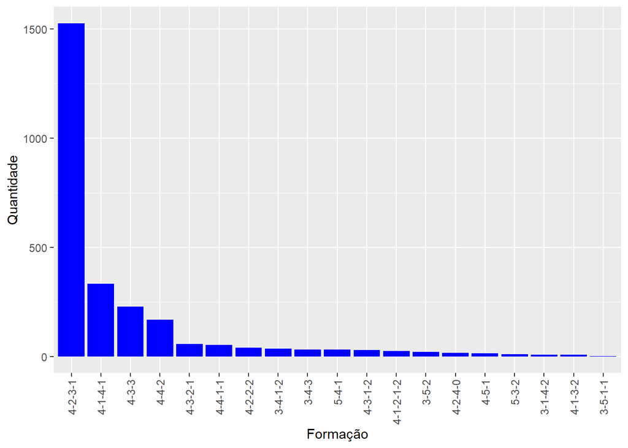

```r
# Ordenar da maior quantidade de vitórias para a menor
idx <- order(tabela$N, decreasing = TRUE)
levels <- tabela$formacao_visitante[idx]
tabela$formacao_visitante <- factor(tabela$formacao_visitante, levels=levels, ordered=TRUE)

# Gráfico
formacoes <- c("4-2-3-1","4-1-4-1","4-3-3","4-4-2","4-2-2-2","4-3-2-1","4-3-1-2","4-4-1-1","3-4-1-2","3-4-1-2","4-1-2-1-2","3-4-3","5-4-1","4-5-1","4-1-3-2","3-5-2","5-3-2","4-2-4-0", "3-1-4-2", "3-2-4-1", "3-5-1-1")

p <- tabela %>% filter(tabela$formacao_visitante%in%formacoes) %>% ggplot(aes(x = formacao_visitante, y = N), na.rm = FALSE)

p + geom_col(position = "dodge2", fill = 'blue') +
  labs(x = "Formação", y = "Quantidade") +
  theme(legend.position = "top",
        axis.text.x = element_text(angle = 90,
                                   vjust = 0.5,
                                   hjust = 1))
```

**Portanto, a formação 4-2-3-1 é praticamente predominante nos times mandantes do campeonato brasileiro, sendo 4-1-4-1, 4-3-3 e 4-4-2 as outras mais utilizadas.**

**Percebe-se que a formação mais utilizada pelos times visitantes é novamente a 4-2-3-1. é muito interessante como, independentemente se o jogo é em casa ou fora, os times mantem a mesma formação.**

#### 1.2.1.6 `dia`:

Vamos repeti o mesmo código, mas agora analisando a `dia`:

```r
tabela <- dados %>%
  group_by(dia) %>%
  summarize(N = n()) %>%
  mutate(freq = N / sum(N), pct = round((freq*100),0))
tabela <- tabela[order(tabela$N,decreasing=TRUE),]
```

Vamos plotar um gráfico para ter essas informaçoes visualmente:

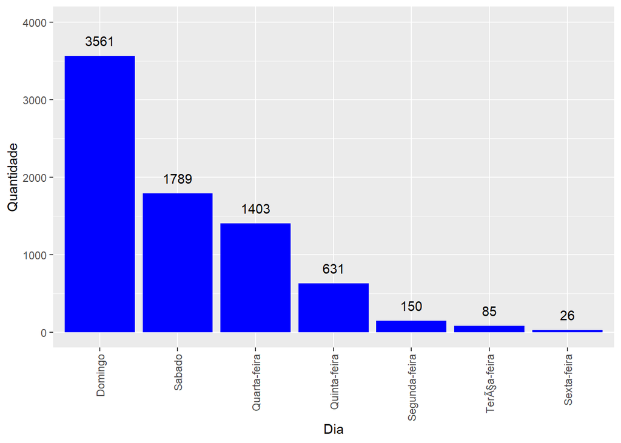

```r
# Ordenar da maior quantidade de vitórias para a menor
idx <- order(tabela$N, decreasing = TRUE)
levels <- tabela$dia[idx]
tabela$dia <- factor(tabela$dia, levels=levels, ordered=TRUE)

# Gráfico
p <- ggplot(data = subset(tabela, !is.na(dia)), aes(x = dia, y = N), na.rm = FALSE)
p + geom_col(position = "dodge2", fill = 'blue') +
  labs(x = "Dia", y = "Quantidade") +
  theme(legend.position = "top",
        axis.text.x = element_text(angle = 90,
                                   vjust = 0.5,
                                   hjust = 1)) +
  geom_text(aes(label = N), vjust = -1) +
  ylim(0, 4000)
```

**Aqui aparece algo muito interessante: a maior parte dos jogos do brasileirão ocorrem no fim de semana. Isso é explicado pois o brasileirão não ocorre em alguns meios de semanas por conta dos campeonatos em formato de copa ocorrerem no meio de semana.**

#### 1.2.1.7 `hora`:

```r
tabela <- dados %>%
  group_by(hora) %>%
  summarize(N = n()) %>%
  mutate(freq = N / sum(N), pct = round((freq*100),0))
tabela <- tabela[order(tabela$N,decreasing=TRUE),]
```

Vamos plotar um gráfico para ter essas informaçoes visualmente:

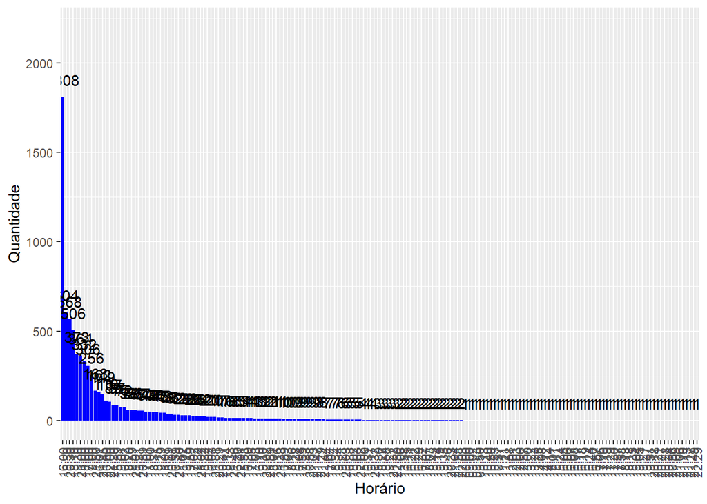

```r
# Ordenar da maior quantidade de vitórias para a menor
idx <- order(tabela$N, decreasing = TRUE)
levels <- tabela$hora[idx]
tabela$hora <- factor(tabela$hora, levels=levels, ordered=TRUE)

# Gráfico
p <- ggplot(data = subset(tabela, !is.na(hora)), aes(x = hora, y = N), na.rm = FALSE)
p + geom_col(position = "dodge2", fill = 'blue') +
  labs(x = "Horário", y = "Quantidade") +
  theme(legend.position = "top",
        axis.text.x = element_text(angle = 90,
                                   vjust = 0.5,
                                   hjust = 1)) +
  geom_text(aes(label = N), vjust = -1) +
  ylim(0, 2200)
```

Novamente, vamos pegar os primeiros:

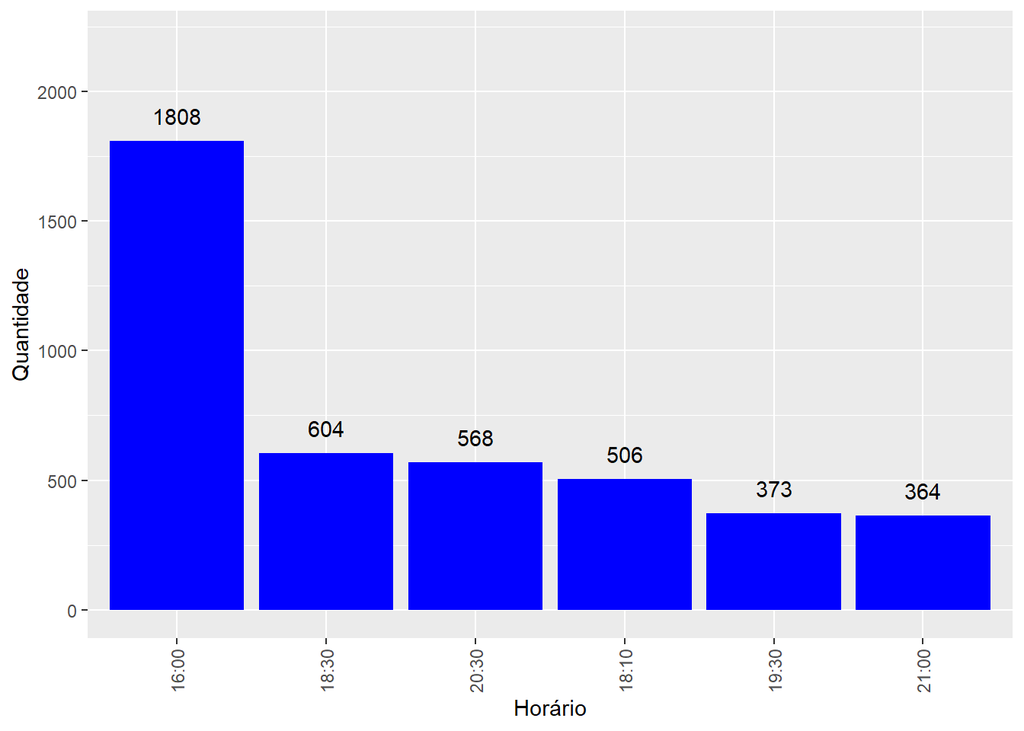

```r
# Ordenar da maior quantidade de vitórias para a menor
idx <- order(tabela$N, decreasing = TRUE)
levels <- tabela$hora[idx]
tabela$hora <- factor(tabela$hora, levels=levels, ordered=TRUE)

# Gráfico
p <- ggplot(head(tabela), aes(x = hora, y = N, na.rm = TRUE))
p + geom_col(position = "dodge2", fill = 'blue') +
  labs(x = "Horário", y = "Quantidade") +
  theme(legend.position = "top",
        axis.text.x = element_text(angle = 90,
                                   vjust = 0.5,
                                   hjust = 1)) +
  geom_text(aes(label = N), vjust = -1) +
  ylim(0, 2200)
```

**É notório que o horário que mais há jogos é o de 16:00. Como visto anteriomente, os dia da semana com mais jogos é o domingo, que é justamente o dia que há jogos às 16:00 e às 18:30. No meio de semana, os jogos costumam ocorrer 20:30 e 21:00.**

### 1.2.2 Variável Quantitativa

As únicas variáveis quantitativas que são interessantes de fazer uma análise são `mandante_placar`, `visitante_placar`. No futuro, elas serão imprescindíveis para as análises bidimensionais.

#### 1.2.2.1 `mandante_placar`

Primeiramente, vamos olhar a frequência da quantidade de gols por partida dos times mandantes:

```r
mandante_placar_frequencia <- table(dados$mandante_placar)
mandante_placar_frequencia
```

```
##
##    0    1    2    3    4    5    6    7
## 1559 2591 1951  997  386  119   36    6
```

Com esses valores, podemos gerar um histograma para melhor visualizar:

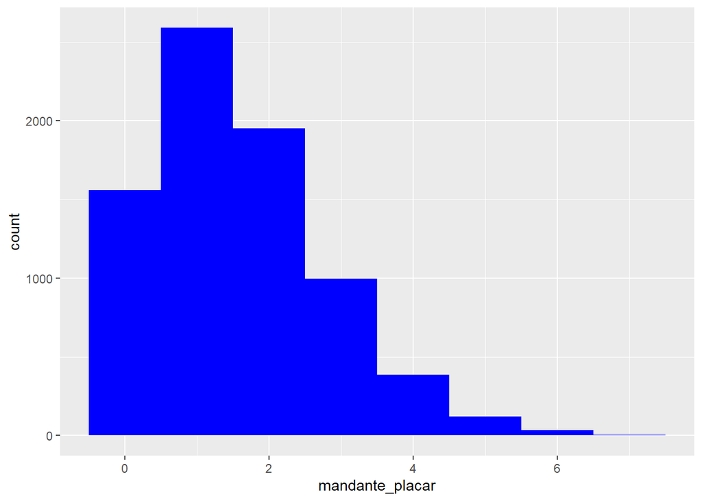

```r
ggplot(data = dados, aes(x = mandante_placar)) +
  geom_histogram(fill = 'blue', bins = 8)
```

**É possível observar que a quantidade de gols se concentra claramente entre 0 a 3 gols por partida, sendo 1 gol o mais comum de ocorrer.**

Agora, vamos observar as estatísticas descritivas e, após gerar também as estatísticas do `mandante_visitante`, compará-las:

```r
#Média
mean(dados$mandante_placar)
```

```
## [1] 1.554088
```

```r
#Mediana
median(dados$mandante_placar)
```

```
## [1] 1
```

```r
#Quartis
quantile(dados$mandante_placar)
```

```
##   0%  25%  50%  75% 100%
##    0    1    1    2    7
```

```r
#Max
max(dados$mandante_placar)
```

```
## [1] 7
```

```r
#Min
min(dados$mandante_placar)
```

```
## [1] 0
```

```r
#Amplitude
diff(range(dados$mandante_placar))
```

```
## [1] 7
```

```r
# Variância
var(dados$mandante_placar)
```

```
## [1] 1.523402
```

```r
# Desvio-padrão
sd(dados$mandante_placar)
```

```
## [1] 1.234262
```

No r há a função `summary()` que resume todo esses dados:

```r
summary(dados$mandante_placar)
```

```
##    Min. 1st Qu.  Median    Mean 3rd Qu.    Max.
##   0.000   1.000   1.000   1.554   2.000   7.000
```

#### 1.2.2.2 `visitante_placar`

Agora, vamos olhar a frequência da quantidade de gols por partida dos visitantes:

```r
visitante_placar_frequencia <- table(dados$visitante_placar)
visitante_placar_frequencia
```

```
##
##    0    1    2    3    4    5    6    7
## 2795 2732 1452  487  149   22    5    3
```

Com esses valores, podemos gerar um histograma para melhor visualizar:

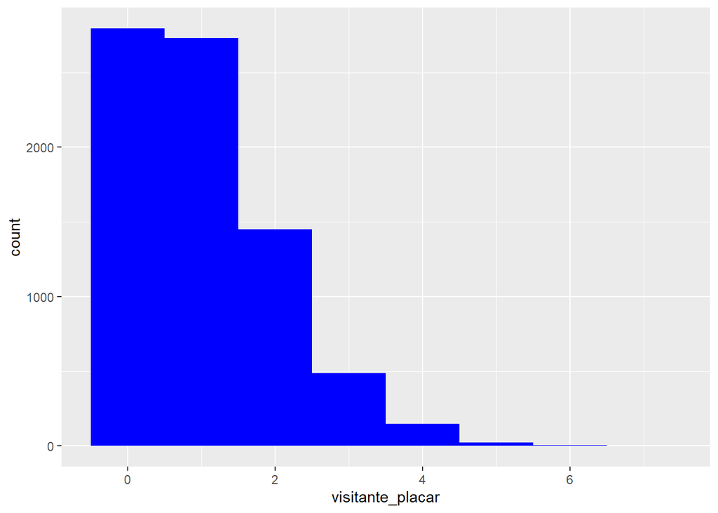

```r
ggplot(data = dados, aes(x = visitante_placar)) +
  geom_histogram(fill = 'blue', bins = 8)
```

**Diferente dos times que jogam em casa, os times visitantes marcaram por volta de 0 a 3 gols por partida. O mais interessante é que a quantidade mais comum de ocorrer é 0 gols por partida, o que difere dos mandantes, que tinham 1 gol como mais comum.**

Agora, vamos observar as estatísticas descritivas

```r
#Média
mean(dados$visitante_placar)
```

```
## [1] 1.027338
```

```r
#Mediana
median(dados$visitante_placar)
```

```
## [1] 1
```

```r
#Quartis
quantile(dados$visitante_placar)
```

```
##   0%  25%  50%  75% 100%
##    0    0    1    2    7
```

```r
#Max
max(dados$visitante_placar)
```

```
## [1] 7
```

```r
#Min
min(dados$visitante_placar)
```

```
## [1] 0
```

```r
#Amplitude
diff(range(dados$visitante_placar))
```

```
## [1] 7
```

```r
# Variância
var(dados$visitante_placar)
```

```
## [1] 1.061654
```

```r
# Desvio-padrão
sd(dados$visitante_placar)
```

```
## [1] 1.030366
```

No r há a função `summary()` que resume todo esses dados:

```r
summary(dados$visitante_placar)
```

```
##    Min. 1st Qu.  Median    Mean 3rd Qu.    Max.
##   0.000   0.000   1.000   1.027   2.000   7.000
```

#### 1.2.2.3 Análise quantitativa

**Percebe-se, portanto, que, ao comparar as médias do número de gols, os mandantes fazem 0,5 a mais de gols nas partidas, uma vez que média de gols dos mandantes é de 1.554088 e dos visitantes é de 1.027338.**

**Isso fornece algo interessante: jogar em casa, por conta da torcida, do ambiente e de não ter que fazer viagens - entre outros fatores - favorece os times, visto que há uma probabilidade maior de marcar gols.**

**É muito fácil perceber isso ao analisar os histogramas gerados, uma vez que, como comentado, a quantidade de gols mais comum de ocorrer para os visitantes é 0 gols por partida, o que difere dos mandantes, que possuem 1 gol como mais comum.**